# An integrative framework for survival modeling and model-agnostic pathway-level variable importance: application to cervical cancer

Published

July 28, 2026

# 1 Context

**Cervical Cancer**

Cervical cancer (CESC) represents the second leading cause of gynecological cancer–related mortality worldwide. Despite advances in screening and early detection, a substantial proportion of patients experience disease recurrence or develop metastatic lesions following standard treatment. In such cases, the prognosis remains poor and accounts for the majority of cervical cancer–related deaths. A major clinical challenge lies in the marked heterogeneity of treatment response, even among patients presenting with similar clinical and pathological stages.

**Research gap**

Although large-scale genomic and transcriptomic studies have provided valuable insights into the molecular landscape of cervical cancer, robust and reproducible biomarkers of treatment response are still lacking. The biological complexity of the disease and the variability in therapeutic sensitivity highlight the need for integrative approaches that can capture pathway-level and system-wide effects beyond individual gene alterations.

**Study objective**

We propose an integrative framework that combines penalized Cox models, likelihood-based boosting, and model-agnostic variable importance to evaluate the added predictive value of pathway-level molecular data (genomic and transcriptomic).

The framework was applied to two independent cervical cancer cohorts (Bio-RAIDs and TCGA-CESC) to quantify the prognostic value of biological pathways and assess the reproducibility of prognostic signals beyond standard clinico-biological covariates.

# 2 Data collection

Primary cervical tumor samples were obtained from patients diagnosed with cervical cancer and included in two independent cohorts. The BIORAIDs cohort (NCT02428842) is a prospective multicenter European study enrolling patients with histologically confirmed cervical carcinoma and available tumor tissue for molecular profiling (Ngo et al. 2015). The TCGA-CESC cohort (The Cancer Genome Atlas – Cervical Squamous Cell Carcinoma and Endocervical Adenocarcinoma) was used as an independent, publicly available dataset for external validation (Lucchesi and Aredes 2016).

**Bio-RAIDs** (Ngo et al. 2015)

We analysed data from patients enrolled in the multicentre European prospective study, Bio-RAIDs (NCT02428842). An extensive DNA and RNA sequencing analysis was performed in evaluable patients to identify potential prognostic molecular biomarkers in cervical cancer patients. In particular, Whole Exome Sequencing (WES), shallow Whole Genome Sequencing (s-WGS) and RNA sequencing (RNA-seq) were conducted. Details on these molecular analyses have already been published.

**The Cancer Genome Atlas (TCGA)** (Lucchesi and Aredes 2016)

The TCGA data portal was used to obtain Copy Number Variation (CNVs), Simple Nucleotide Variation (SNVs) and RNA gene expression data and corresponding clinical information for CESC patients. Progression-Free survival was derived from the harmonized Pan-Cancer Clinical Data Resource (TCGA-CDR) described by Liu *et al.*. This resource provides standardized and curated survival outcomes across all TCGA tumor types, enabling consistent time-to-event analyses.

# 3 Overall analytical workflow

The overall analytical workflow is illustrated in Figure 1.

Figure 1: Overall analysis workflow

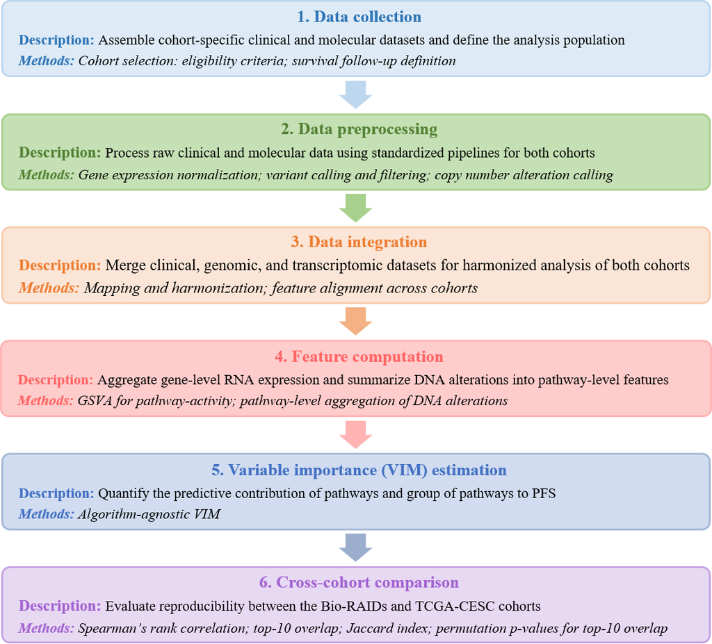

# 4 List of pathways

Table 1: Description of the DNA-based pathways

| **N°** | **Pathway** | **Process category** |
| --- | --- | --- |
| 1 | Adhesion/Migration | Cellular component |
| 2 | DNA repair | DNA damage |
| 3 | Genome integrity via p53 | DNA damage |
| 4 | Chromatin organization | Epigenetics |
| 5 | Epigenetics | Epigenetics |
| 6 | Immunity | Immune |
| 7 | JAK/STAT | Immune |
| 8 | Cellular metabolism | Metabolic |
| 9 | Regulation of gene expression | Metabolic |
| 10 | Transcriptional regulator | Metabolic |
| 11 | mRNA processing | Metabolic |
| 12 | Apoptosis | Pathway |
| 13 | Oxidative stress | Pathway |
| 14 | Proteins processing | Pathway |
| 15 | Cell cycle | Proliferation |
| 16 | Myc | Proliferation |
| 17 | Senescence | Proliferation |
| 18 | Hedgehog | Signaling |
| 19 | Hippo | Signaling |
| 20 | MAPK | Signaling |
| 21 | Notch | Signaling |
| 22 | PI3K | Signaling |
| 23 | RTK/RAS | Signaling |
| 24 | TGF-β | Signaling |
| 25 | Wnt | Signaling |

Table 2: Description of the RNA-based pathways

| **N°** | **Pathway** | **Process category** |
| --- | --- | --- |
| 1 | Apical junction | Cellular component |
| 2 | Apical surface | Cellular component |
| 3 | Peroxisome | Cellular component |
| 4 | DNA repair | DNA damage |
| 5 | UV response: down-regulated genes | DNA damage |
| 6 | UV response: up-regulated genes | DNA damage |
| 7 | Adipogenesis | Development |
| 8 | Angiogenesis | Development |
| 9 | Epithelial mesenchymal transition | Development |
| 10 | Myogenesis | Development |
| 11 | Pancreas β cells | Development |
| 12 | Spermatogenesis | Development |
| 13 | Allograft rejection | Immune |
| 14 | Coagulation | Immune |
| 15 | Complement | Immune |
| 16 | IL6/JAK/STAT3 | Immune |
| 17 | Inflammatory response | Immune |
| 18 | Interferon α response | Immune |
| 19 | Interferon γ response | Immune |
| 20 | Bile acide metabolism | Metabolic |
| 21 | Cholesterol homeostasis | Metabolic |
| 22 | Fatty acid metabolism | Metabolic |
| 23 | Glycolysis | Metabolic |
| 24 | Heme metabolism | Metabolic |
| 25 | Oxidative phosphorylation | Metabolic |
| 26 | Xenobiotic metabolism | Metabolic |
| 27 | Apoptosis | Pathway |
| 28 | Hypoxia | Pathway |
| 29 | Protein secretion | Pathway |
| 30 | Reactive oxygen species | Pathway |
| 31 | Unfolded protein response | Pathway |
| 32 | E2F targets | Proliferation |
| 33 | G2M checkpoint | Proliferation |
| 34 | Mitotic spindle | Proliferation |
| 35 | Myc targets variant 1 | Proliferation |
| 36 | Myc targets variant 2 | Proliferation |
| 37 | p53 | Proliferation |
| 38 | Androgen response | Signaling |
| 39 | Early estrogen response | Signaling |
| 40 | Hedgehog | Signaling |
| 41 | IL2/STAT5 | Signaling |
| 42 | KRAS: down-regulated genes | Signaling |
| 43 | KRAS: up-regulated genes | Signaling |
| 44 | Late estrogen response | Signaling |
| 45 | MTORC1 | Signaling |
| 46 | Notch | Signaling |
| 47 | PI3K/AKT/MTOR | Signaling |
| 48 | TGF-β | Signaling |
| 49 | TNF-α/NF-κB | Signaling |
| 50 | Wnt/β-catenin | Signaling |

# 5 Descriptive statistics

## 5.1 Venn diagrams of patient distribution by omics and clinical data

Venn diagrams illustrating the distribution of patients according to the availability of omics and clinical data is shown in Figure 2.

Figure 2: Venn diagrams of patient distribution by omics and clinical data

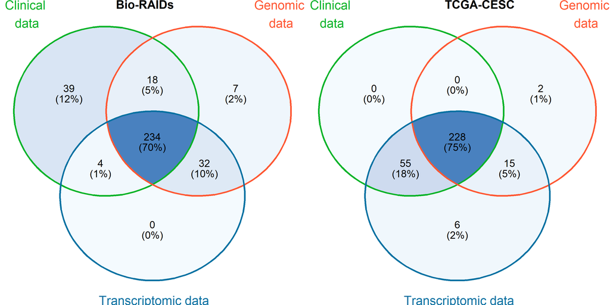

## 5.2 Patients’ characteristics

Patients’ characteristics are presented in Table 3.

Table 3: Patients’ characteristics

|  | **Bio-RAIDs** N = 234 | **TCGA-CESC** N = 228 | **p-value** |
| --- | --- | --- | --- |
| Age |  |  | 0.002 |
| >50 | 124 (53%) | 88 (39%) |  |
| ≤50 | 110 (47%) | 140 (61%) |  |
| FIGO stage |  |  | <0.001 |
| I/II | 76 (32%) | 180 (79%) |  |
| III/IV | 158 (68%) | 48 (21%) |  |
| Histology |  |  | 0.12 |
| Squamous cell carcinoma | 194 (83%) | 187 (82%) |  |
| Adenocarcinoma | 29 (12%) | 37 (16%) |  |
| Other | 11 (5%) | 4 (2%) |  |
| HPV status |  |  | 0.094 |
| Positive | 222 (95%) | 223 (98%) |  |
| Negative | 12 (5%) | 5 (2%) |  |

## 5.3 Pathway-level frequencies of DNA alterations

The pathway-level frequencies of DNA alterations in both cohorts are illustrated in Figure 3.

Figure 3: Pathway-level frequencies of DNA alterations across the BIORAIDs and TCGA-CESC cohorts

[figure not shown]

## 5.4 Distribution of RNA-based pathway activity scores

The distribution of RNA-based pathway activity scores in both cohorts is illustrated in Figure 4.

Figure 4: Distribution of RNA-based pathway activity scores across the BIORAIDs and TCGA-CESC cohorts

[figure not shown]

## 5.5 Relationships between RNA-based pathways

Figure 5: Correlation matrix of RNA-based pathway activity scores across the BIORAIDs and TCGA-CESC cohorts

(a) Bio-RAIDs

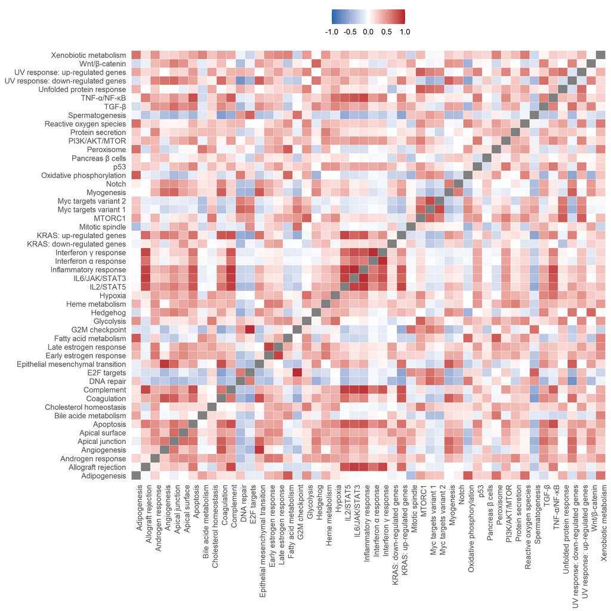

(b) TCGA-CESC

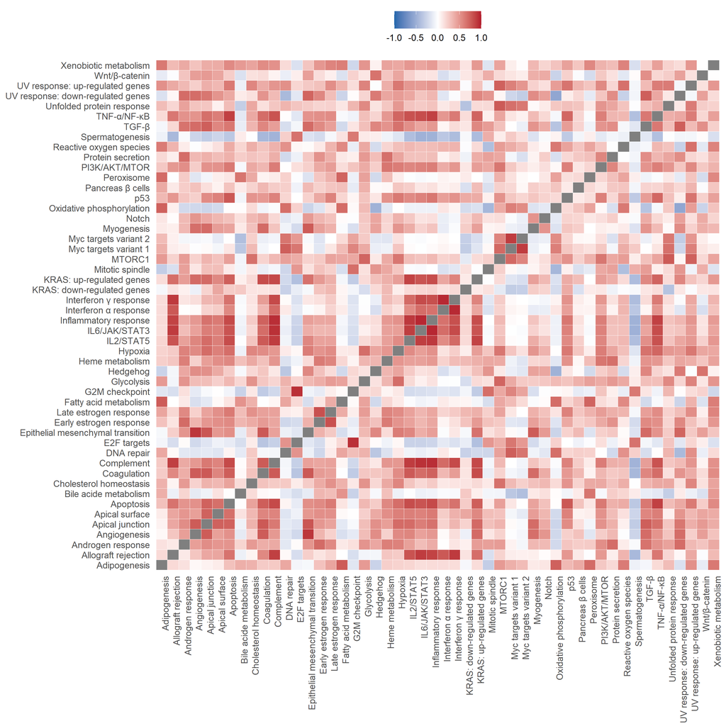

# 6 Kaplan-Meier estimated progression-free survival

Progression-free survival (PFS) in both cohorts is shown in Figure 6.

Figure 6: Progression-free survival (PFS) curves in both cohorts

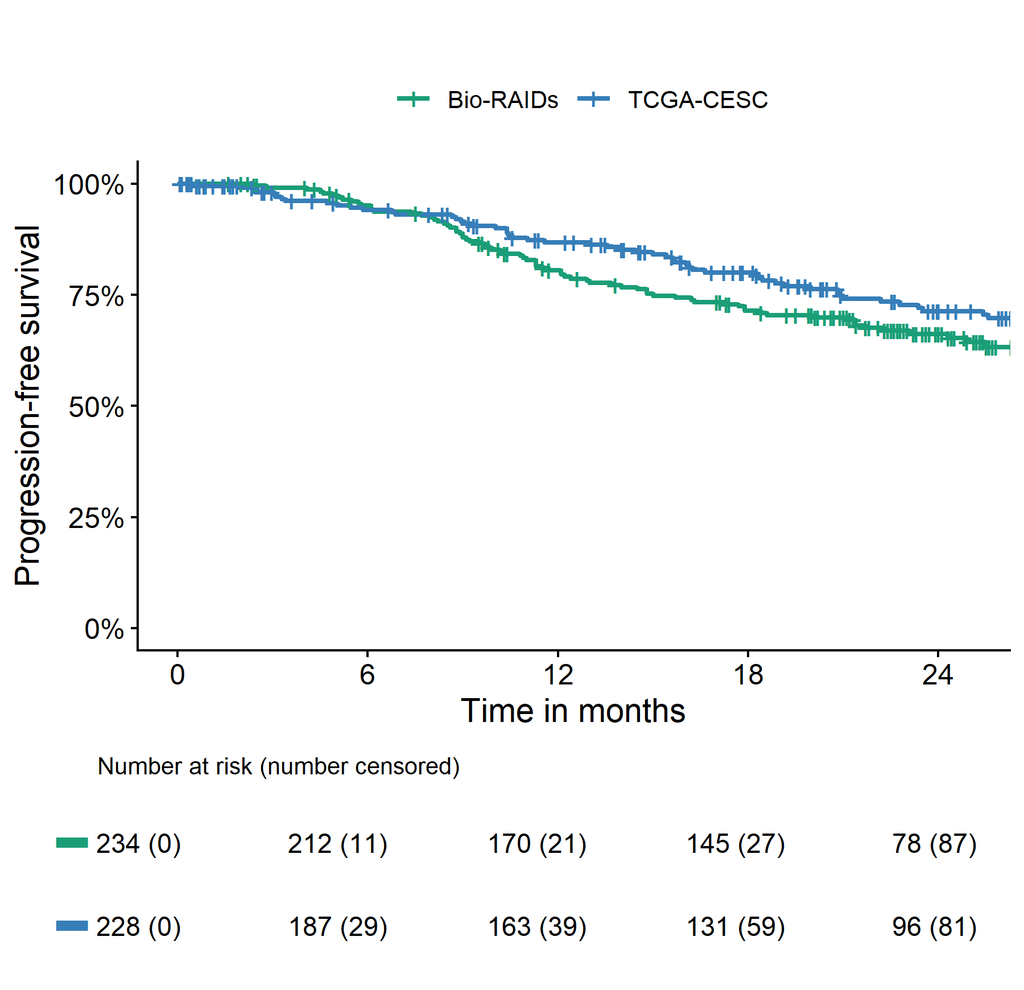

# 7 Global test

We used the global test framework to evaluate whether the sets of variables were associated with progression-free survival (Goeman et al. 2004). The analysis was conducted independently in each cohort.

Table 4: Global test

[output not shown]

Clinical: clinical features; DNA: gene-level DNA alterations features; RNA: gene-level expression features; DNA_pathways: DNA-based pathways features; RNA_pathways: RNA-based pathways features

# 8 Cox regression

Table 5: Univariate Cox regression analysis of clinico-biological covariates

|  | **Bio-RAIDs** **N** | **Bio-RAIDs** **Event N** | **Bio-RAIDs** **HR [95% CI]** | **Bio-RAIDs** **p-value** | **TCGA-CESC** **N** | **TCGA-CESC** **Event N** | **TCGA-CESC** **HR [95% CI]** | **TCGA-CESC** **p-value** |
| --- | --- | --- | --- | --- | --- | --- | --- | --- |
| Age |  |  |  | 0.6 |  |  |  | 0.058 |
| >50 | 124 | 43 | — |  | 88 | 35 | — |  |
| ≤50 | 110 | 37 | 0.88 [0.56 - 1.36] |  | 140 | 32 | 0.63 [0.39 - 1.01] |  |
| FIGO stage |  |  |  | <0.001 |  |  |  | 0.15 |
| I/II | 76 | 13 | — |  | 180 | 49 | — |  |
| III/IV | 158 | 67 | 3.31 [1.82 - 5.99] |  | 48 | 18 | 1.51 [0.88 - 2.60] |  |
| HPV status |  |  |  | 0.3 |  |  |  | >0.9 |
| Positive | 222 | 75 | — |  | 223 | 66 | — |  |
| Negative | 12 | 5 | 1.61 [0.65 - 3.98] |  | 5 | 1 | 0.96 [0.13 - 6.95] |  |

Abbreviations: CI = Confidence Interval, HR = Hazard Ratio

Table 6: Multivariate Cox regression analysis of clinico-biological covariates

|  | **Bio-RAIDs** **N** | **Bio-RAIDs** **Event N** | **Bio-RAIDs** **HR [95% CI]** | **Bio-RAIDs** **p-value** | **TCGA-CESC** **N** | **TCGA-CESC** **Event N** | **TCGA-CESC** **HR [95% CI]** | **TCGA-CESC** **p-value** |
| --- | --- | --- | --- | --- | --- | --- | --- | --- |
| Age |  |  |  | 0.8 |  |  |  | 0.10 |
| >50 | 124 | 43 | — |  | 88 | 35 | — |  |
| ≤50 | 110 | 37 | 0.93 [0.60 - 1.45] |  | 140 | 32 | 0.66 [0.40 - 1.08] |  |
| FIGO stage |  |  |  | <0.001 |  |  |  | 0.3 |
| I/II | 76 | 13 | — |  | 180 | 49 | — |  |
| III/IV | 158 | 67 | 3.26 [1.79 - 5.92] |  | 48 | 18 | 1.38 [0.79 - 2.41] |  |
| HPV status |  |  |  | 0.7 |  |  |  | 0.7 |
| Positive | 222 | 75 | — |  | 223 | 66 | — |  |
| Negative | 12 | 5 | 1.23 [0.49 - 3.09] |  | 5 | 1 | 0.69 [0.09 - 5.07] |  |

Abbreviations: CI = Confidence Interval, HR = Hazard Ratio

# 9 Cox regression with likelihood-based boosting

Cox models with likelihood-based boosting were built to identify prognostic factors for progression-free survival in the Bio-RAIDs cohort (Binder and Schumacher 2008). An integrative multi-omics analysis was performed, jointly modeling clinical variables together with genomic and transcriptomic data at gene level. Only patients with available clinical, genomic, and transcriptomic data were included in the analysis. Clinical variables were incorporated as unpenalized mandatory covariates, ensuring their systematic inclusion. These features were favored by setting them as an offset in the model. Molecular variables comprised gene-level DNA alterations and gene expression profiles derived from RNA-Seq and were subjected to boosting-based selection. A 10-fold cross-validation was used to determine the optimal number of boosting steps with respect to the partial log-likelihood.

Figure 7: Estimated coefficients of selected omic features from the likelihood-based boosting Cox model in the Bio-RAIDs cohort

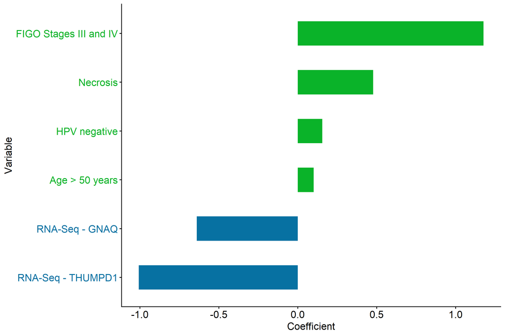

# 10 Variable importance using random survival forests (`survex`,`ranger`)

This section illustrates the estimation of variable importance using a random survival forest fitted with the `ranger` package and explained with `survex`. We evaluated predictive performance for progression-free survival using the time-dependent AUC at the 24-month prediction horizon.

## 10.1 DNA-based pathways

Figure 8: Variable importance estimates of DNA-based pathways using using random survival forests

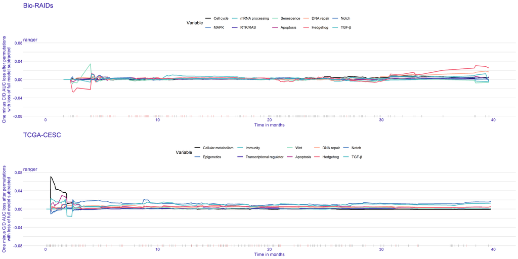

Figure 9: Variable importance estimates of DNA-based pathways at 24 months using random survival forests

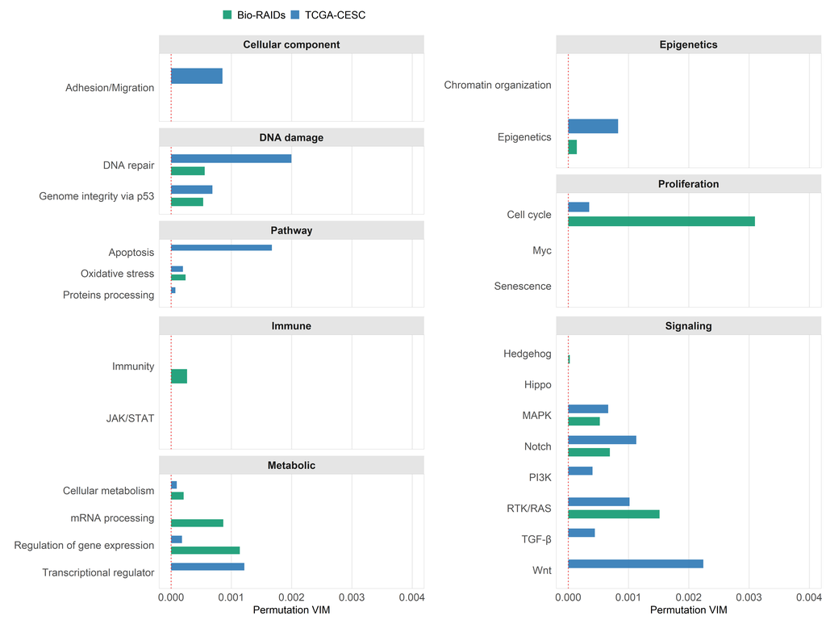

Table 7: Variable importance estimates of DNA-based pathways

| **Pathway** | **Bio-RAIDs** | **TCGA-CESC** |
| --- | --- | --- |
| Adhesion/Migration | 0.000 | 0.001 |
| DNA repair | 0.001 | 0.002 |
| Genome integrity via p53 | 0.001 | 0.001 |
| Chromatin organization | 0.000 | 0.000 |
| Epigenetics | 0.000 | 0.001 |
| Immunity | 0.000 | 0.000 |
| JAK/STAT | 0.000 | 0.000 |
| Cellular metabolism | 0.000 | 0.000 |
| Regulation of gene expression | 0.001 | 0.000 |
| Transcriptional regulator | 0.000 | 0.001 |
| mRNA processing | 0.001 | 0.000 |
| Apoptosis | 0.000 | 0.002 |
| Oxidative stress | 0.000 | 0.000 |
| Proteins processing | 0.000 | 0.000 |
| Cell cycle | 0.003 | 0.000 |
| Myc | 0.000 | 0.000 |
| Senescence | 0.000 | 0.000 |
| Hedgehog | 0.000 | 0.000 |
| Hippo | 0.000 | 0.000 |
| MAPK | 0.001 | 0.001 |
| Notch | 0.001 | 0.001 |
| PI3K | 0.000 | 0.000 |
| RTK/RAS | 0.002 | 0.001 |
| TGF-β | 0.000 | 0.000 |
| Wnt | 0.000 | 0.002 |

VIM: variable importance measure

## 10.2 DNA-based functional categories

Figure 10: Variable importance estimates of DNA-based functional categories using random survival forests

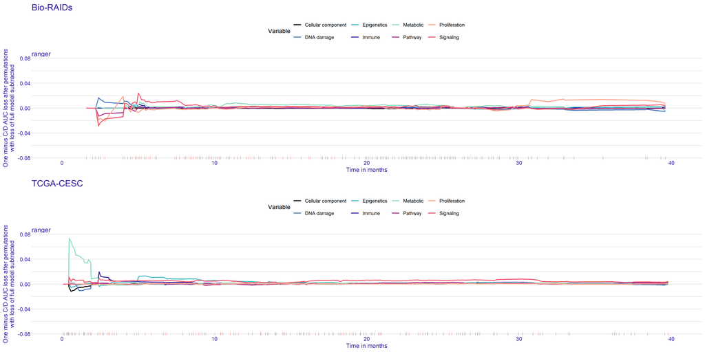

Figure 11: Variable importance estimates of DNA-based functional categories at 24 months using random survival forests

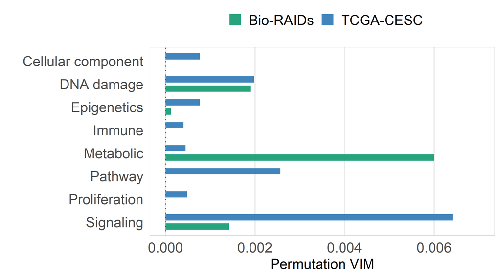

Table 8: Variable importance estimates of DNA-based functional categories

| **Pathway** | **Bio-RAIDs** | **TCGA-CESC** |
| --- | --- | --- |
| Cellular component | 0.000 | 0.001 |
| DNA damage | 0.002 | 0.002 |
| Epigenetics | 0.000 | 0.001 |
| Immune | 0.000 | 0.000 |
| Metabolic | 0.006 | 0.000 |
| Pathway | 0.000 | 0.003 |
| Proliferation | 0.000 | 0.000 |
| Signaling | 0.001 | 0.006 |

VIM: variable importance measure

## 10.3 RNA-based pathways

Figure 12: Variable importance estimates of RNA-based pathways using random survival forests

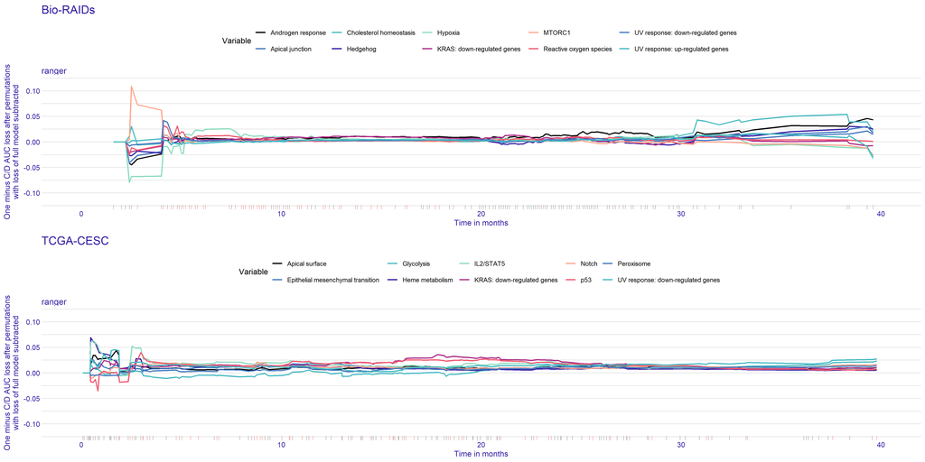

Figure 13: Variable importance estimates of RNA-based pathways at 24 months using random survival forests

[figure not shown]

Table 9: Variable importance estimates of RNA-based pathways

| **Pathway** | **Bio-RAIDs** | **TCGA-CESC** |
| --- | --- | --- |
| Apical junction | 0.004 | 0.007 |
| Apical surface | 0.000 | 0.012 |
| Peroxisome | 0.000 | 0.012 |
| DNA repair | 0.001 | 0.002 |
| UV response: down-regulated genes | 0.003 | 0.015 |
| UV response: up-regulated genes | 0.002 | 0.003 |
| Adipogenesis | 0.000 | 0.009 |
| Angiogenesis | 0.000 | 0.007 |
| Epithelial mesenchymal transition | 0.000 | 0.009 |
| Myogenesis | 0.000 | 0.006 |
| Pancreas β cells | 0.000 | 0.009 |
| Spermatogenesis | 0.000 | 0.002 |
| Allograft rejection | 0.002 | 0.009 |
| Coagulation | 0.001 | 0.006 |
| Complement | 0.000 | 0.004 |
| IL6/JAK/STAT3 | 0.000 | 0.006 |
| Inflammatory response | 0.000 | 0.009 |
| Interferon α response | 0.000 | 0.005 |
| Interferon γ response | 0.000 | 0.002 |
| Bile acide metabolism | 0.003 | 0.005 |
| Cholesterol homeostasis | 0.005 | 0.016 |
| Fatty acid metabolism | 0.001 | 0.004 |
| Glycolysis | 0.000 | 0.015 |
| Heme metabolism | 0.002 | 0.008 |
| Oxidative phosphorylation | 0.004 | 0.007 |
| Xenobiotic metabolism | 0.000 | 0.005 |
| Apoptosis | 0.000 | 0.002 |
| Hypoxia | 0.004 | 0.007 |
| Protein secretion | 0.000 | 0.002 |
| Reactive oxygen species | 0.007 | 0.011 |
| Unfolded protein response | 0.000 | 0.004 |
| E2F targets | 0.000 | 0.007 |
| G2M checkpoint | 0.000 | 0.004 |
| Mitotic spindle | 0.000 | 0.004 |
| Myc targets variant 1 | 0.002 | 0.009 |
| Myc targets variant 2 | 0.000 | 0.005 |
| p53 | 0.005 | 0.018 |
| Androgen response | 0.012 | 0.010 |
| Early estrogen response | 0.000 | 0.003 |
| Hedgehog | 0.000 | 0.000 |
| IL2/STAT5 | 0.000 | 0.019 |
| KRAS: down-regulated genes | 0.007 | 0.022 |
| KRAS: up-regulated genes | 0.000 | 0.006 |
| Late estrogen response | 0.000 | 0.007 |
| MTORC1 | 0.001 | 0.008 |
| Notch | 0.001 | 0.001 |
| PI3K/AKT/MTOR | 0.000 | 0.005 |
| TGF-β | 0.000 | 0.000 |
| TNF-α/NF-κB | 0.003 | 0.002 |
| Wnt/β-catenin | 0.000 | 0.005 |

VIM: variable importance measure

## 10.4 RNA-based functional categories

Figure 14: Variable importance estimates of RNA-based functional categories using random survival forests

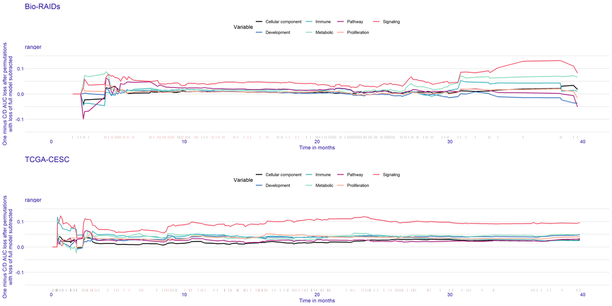

Figure 15: Variable importance estimates of RNA-based functional categories at 24 months using random survival forests

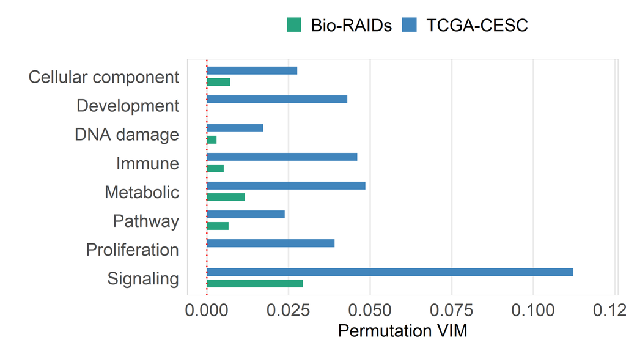

Table 10: Variable importance estimates of RNA-based functional categories

| **Pathway** | **Bio-RAIDs** | **TCGA-CESC** |
| --- | --- | --- |
| Cellular component | 0.007 | 0.028 |
| DNA damage | 0.003 | 0.017 |
| Development | 0.000 | 0.043 |
| Immune | 0.005 | 0.046 |
| Metabolic | 0.012 | 0.049 |
| Pathway | 0.007 | 0.024 |
| Proliferation | 0.000 | 0.039 |
| Signaling | 0.029 | 0.112 |

VIM: variable importance measure

## 10.5 Top-10 features

Table 11: Top-10 variable importance estimates of DNA-based pathways using random survival forests

| **Rank** | **Bio-RAIDs** **Pathway** | **Bio-RAIDs** **VIM** | **TCGA-CESC** **Pathway** | **TCGA-CESC** **VIM** |
| --- | --- | --- | --- | --- |
| 1 | Cell cycle | 0.003 | Wnt | 0.002 |
| 2 | RTK/RAS† | 0.002 | DNA repair† | 0.002 |
| 3 | Regulation of gene expression | 0.001 | Apoptosis | 0.002 |
| 4 | mRNA processing | 0.001 | Transcriptional regulator | 0.001 |
| 5 | Notch† | 0.001 | Notch† | 0.001 |
| 6 | DNA repair† | 0.001 | RTK/RAS† | 0.001 |
| 7 | Genome integrity via p53† | 0.001 | Adhesion/Migration | 0.001 |
| 8 | MAPK† | 0.001 | Epigenetics | 0.001 |
| 9 | Immunity | 0.000 | Genome integrity via p53† | 0.001 |
| 10 | Oxidative stress | 0.000 | MAPK† | 0.001 |

VIM: variable importance measure; † Pathway ranked among the top 10 in both Bio-RAIDs and TCGA-CESC

Table 12: Top-10 variable importance estimates of DNA-based functional categories using random survival forests

| **Rank** | **Bio-RAIDs** **Pathway** | **Bio-RAIDs** **VIM** | **TCGA-CESC** **Pathway** | **TCGA-CESC** **VIM** |
| --- | --- | --- | --- | --- |
| 1 | Metabolic | 0.006 | Signaling | 0.006 |
| 2 | DNA damage | 0.002 | Pathway | 0.003 |
| 3 | Signaling | 0.001 | DNA damage | 0.002 |
| 4 | Epigenetics | 0.000 | Cellular component | 0.001 |
| 5 | Cellular component | 0.000 | Epigenetics | 0.001 |
| 6 | Immune | 0.000 | Proliferation | 0.000 |
| 7 | Pathway | 0.000 | Metabolic | 0.000 |
| 8 | Proliferation | 0.000 | Immune | 0.000 |

VIM: variable importance measure

Table 13: Top-10 variable importance estimates of RNA-based pathways using random survival forests

| **Rank** | **Bio-RAIDs** **Pathway** | **Bio-RAIDs** **VIM** | **TCGA-CESC** **Pathway** | **TCGA-CESC** **VIM** |
| --- | --- | --- | --- | --- |
| 1 | Androgen response† | 0.012 | KRAS: down-regulated genes† | 0.022 |
| 2 | Reactive oxygen species† | 0.007 | IL2/STAT5 | 0.019 |
| 3 | KRAS: down-regulated genes† | 0.007 | p53† | 0.018 |
| 4 | Cholesterol homeostasis† | 0.005 | Cholesterol homeostasis† | 0.016 |
| 5 | p53† | 0.005 | Glycolysis | 0.015 |
| 6 | Apical junction | 0.004 | UV response: down-regulated genes† | 0.015 |
| 7 | Oxidative phosphorylation | 0.004 | Apical surface | 0.012 |
| 8 | Hypoxia | 0.004 | Peroxisome | 0.012 |
| 9 | UV response: down-regulated genes† | 0.003 | Reactive oxygen species† | 0.011 |
| 10 | TNF-α/NF-κB | 0.003 | Androgen response† | 0.010 |

VIM: variable importance measure; † Pathway ranked among the top 10 in both Bio-RAIDs and TCGA-CESC

Table 14: Top-10 variable importance estimates of RNA-based functional categories using random survival forests

| **Rank** | **Bio-RAIDs** **Pathway** | **Bio-RAIDs** **VIM** | **TCGA-CESC** **Pathway** | **TCGA-CESC** **VIM** |
| --- | --- | --- | --- | --- |
| 1 | Signaling | 0.029 | Signaling | 0.112 |
| 2 | Metabolic | 0.012 | Metabolic | 0.049 |
| 3 | Cellular component | 0.007 | Immune | 0.046 |
| 4 | Pathway | 0.007 | Development | 0.043 |
| 5 | Immune | 0.005 | Proliferation | 0.039 |
| 6 | DNA damage | 0.003 | Cellular component | 0.028 |
| 7 | Development | 0.000 | Pathway | 0.024 |
| 8 | Proliferation | 0.000 | DNA damage | 0.017 |

VIM: variable importance measure

## 10.6 Cross-cohort reproducibility

Figure 16: Cross-cohort concordance of pathway-level variable importance estimates using random survival forests

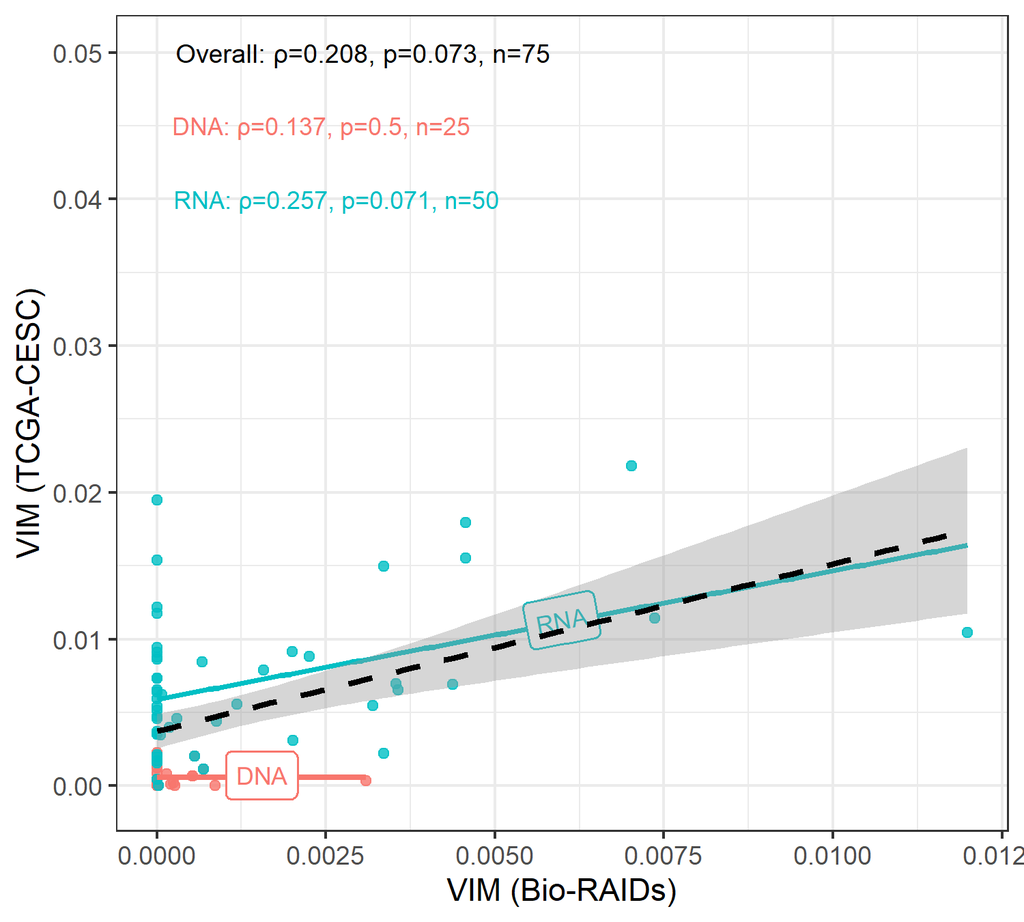

Cross-cohort reproducibility was assessed using complementary measures of agreement, including Spearman’s rank correlation, top-10 pathway overlap, the Jaccard index, and a permutation test evaluating whether the observed overlap exceeded that expected by chance (Table 15).

Table 15: Summary of cross-cohort reproducibility metrics for pathway-level variable importance rankings using random survival forests

(a) Top-5

| Metric | DNA | RNA | Overall |
| --- | --- | --- | --- |
| Spearman's ρ | 0.137 | 0.257 | 0.208 |
| Spearman's p-value | 0.5 | 0.071 | 0.073 |
| Top-5 overlap (%) | 20 | 60 | 60 |
| Top-5 overlapping features | Notch | KRAS: down-regulated genes, Cholesterol homeostasis, p53 | KRAS: down-regulated genes, Cholesterol homeostasis, p53 |
| Jaccard index | 0.11 | 0.43 | 0.43 |
| Permutation p-value (top-5 overlap) | 0.7 | 0.005 | 0.002 |

(b) Top-10

| Metric | DNA | RNA | Overall |
| --- | --- | --- | --- |
| Spearman's ρ | 0.137 | 0.257 | 0.208 |
| Spearman's p-value | 0.5 | 0.071 | 0.073 |
| Top-10 overlap (%) | 50 | 60 | 60 |
| Top-10 overlapping features | RTK/RAS, Notch, DNA repair, Genome integrity via p53, MAPK | Androgen response, Reactive oxygen species, KRAS: down-regulated genes, Cholesterol homeostasis, p53, UV response: down-regulated genes | Androgen response, Reactive oxygen species, KRAS: down-regulated genes, Cholesterol homeostasis, p53, UV response: down-regulated genes |
| Jaccard index | 0.33 | 0.43 | 0.43 |
| Permutation p-value (top-10 overlap) | 0.3 | 0.002 | <0.001 |

(c) Top-20

| Metric | DNA | RNA | Overall |
| --- | --- | --- | --- |
| Spearman's ρ | 0.137 | 0.257 | 0.208 |
| Spearman's p-value | 0.5 | 0.071 | 0.073 |
| Top-20 overlap (%) | 85 | 50 | 45 |
| Top-20 overlapping features | Cell cycle, RTK/RAS, Regulation of gene expression, Notch, DNA repair, Genome integrity via p53, MAPK, Immunity, Oxidative stress, Cellular metabolism, Epigenetics, Adhesion/Migration, Chromatin organ… | Androgen response, Reactive oxygen species, KRAS: down-regulated genes, Cholesterol homeostasis, p53, UV response: down-regulated genes, Myc targets variant 1, Allograft rejection, Heme metabolism, MT… | Androgen response, Reactive oxygen species, KRAS: down-regulated genes, Cholesterol homeostasis, p53, UV response: down-regulated genes, Myc targets variant 1, Allograft rejection, Heme metabolism |
| Jaccard index | 0.74 | 0.33 | 0.29 |
| Permutation p-value (top-20 overlap) | 0.3 | 0.2 | 0.051 |

# 11 Permutation variable importance using random survival forests (`ranger`)

Table 16: Top-10 variable importance estimates of DNA-based pathways relative to the base clinical model

| **Rank** | **Bio-RAIDs** **Pathway** | **Bio-RAIDs** **VIM** | **TCGA-CESC** **Pathway** | **TCGA-CESC** **VIM** |
| --- | --- | --- | --- | --- |
| 1 | Senescence† | 0.0041 | Chromatin organization† | 0.0003 |
| 2 | mRNA processing | 0.0012 | Genome integrity via p53† | 0.0003 |
| 3 | Cell cycle | 0.0010 | TGF-β | 0.0002 |
| 4 | Oxidative stress† | 0.0004 | Notch | 0.0002 |
| 5 | Epigenetics† | 0.0004 | Apoptosis | 0.0002 |
| 6 | DNA repair | 0.0003 | Epigenetics† | 0.0001 |
| 7 | PI3K | 0.0001 | Cellular metabolism | 0.0000 |
| 8 | Chromatin organization† | 0.0001 | Senescence† | 0.0000 |
| 9 | Hedgehog† | 0.0001 | Oxidative stress† | 0.0000 |
| 10 | Genome integrity via p53† | 0.0001 | Hedgehog† | 0.0000 |

VIM: variable importance measure; † Pathway ranked among the top 10 in both Bio-RAIDs and TCGA-CESC

Table 17: Top-10 variable importance estimates of RNA-based pathways relative to the base clinical model

| **Rank** | **Bio-RAIDs** **Pathway** | **Bio-RAIDs** **VIM** | **TCGA-CESC** **Pathway** | **TCGA-CESC** **VIM** |
| --- | --- | --- | --- | --- |
| 1 | KRAS: down-regulated genes† | 0.0099 | KRAS: down-regulated genes† | 0.0065 |
| 2 | Cholesterol homeostasis† | 0.0078 | p53 | 0.0059 |
| 3 | UV response: up-regulated genes | 0.0049 | Glycolysis† | 0.0052 |
| 4 | Hypoxia | 0.0037 | UV response: down-regulated genes† | 0.0038 |
| 5 | Heme metabolism | 0.0036 | IL2/STAT5 | 0.0037 |
| 6 | Androgen response | 0.0028 | Notch | 0.0036 |
| 7 | Unfolded protein response | 0.0026 | Cholesterol homeostasis† | 0.0034 |
| 8 | Glycolysis† | 0.0026 | Peroxisome | 0.0027 |
| 9 | Interferon γ response | 0.0019 | Allograft rejection | 0.0019 |
| 10 | UV response: down-regulated genes† | 0.0017 | Protein secretion | 0.0019 |

VIM: variable importance measure; † Pathway ranked among the top 10 in both Bio-RAIDs and TCGA-CESC

# 12 Variable importance using Super Learner (`survML`,`SuperLearner`)

Variable importance estimation was conducted within a model-agnostic framework for survival data, as proposed by Wolock (2024) (Wolock et al. 2024). The analysis was implemented using the `survML` framework, which integrates several machine learning algorithms. In particular, the `stackG()` function was used to estimate conditional survival functions, while `SuperLearner()` constructed an oracle prediction function by optimally combining multiple learners. To enhance robustness and mitigate overfitting, we employed **five-fold cross-fitting** throughout the estimation procedure. The clinical endpoint of interest was **progression-free survival (PFS)**, and model performance was assessed using the time-dependent **area under the curve (AUC), defined as the area under the cumulative (or dynamic) ROC curve**. All analyses were performed up to a **24-month** time horizon, corresponding to two years of follow-up. We computed *VIM point estimates* for all variables of interest and their corresponding *95% confidence interval (CI)*. We also estimated p-values for the *zero-importance null hypothesis*, which tests whether a variable contributes significantly to prediction beyond random noise.

## 12.1 Variable importance relative to base model in the Bio-RAIDs and TCGA-CESC cohorts

In this analysis, we extended the estimation of variable importance measures (VIMs) to two independent datasets: the BIORAIDs and TCGA-CESC cohorts. We refined our approach by computing VIMs relative to the base clinical model, rather than relative to all features. This modification reduces the influence of correlations among pathways and enables a clearer assessment of the additional prognostic information provided by each molecular feature beyond that explained by age, FIGO stage, and HPV status. In other words, this revised framework focuses on the incremental importance of each pathway, enhancing interpretability and mitigating redundancy among molecular variables.

Table 18: Candidate learners in the Super Learner ensemble along with their R implementation, and tuning parameter values

| Candidate learner | R implementation | Parameters | Tuning parameters |
| --- | --- | --- | --- |
| Marginal mean | SL.mean | NA | NA |
| Ridge | SL.glmnet | alpha = 0 standardize = TRUE | NA |
| Gradient boosted trees | SL.xgboost | Default | ntrees ∈ {250, 500, 1000} max.depth ∈ {1, 2, 4} |
| Random forest | SL.ranger | Default | num.trees ∈ {250, 500, 1000} |

### 12.1.1 DNA-based pathways

Figure 17: Variable importance estimates of DNA-based pathways relative to the base clinical model

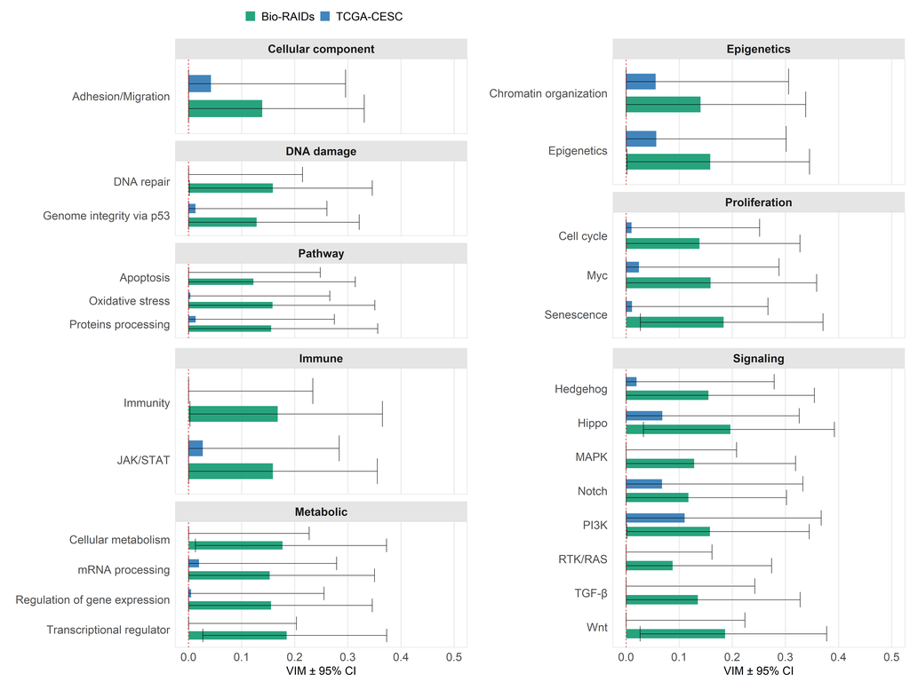

Table 19: Variable importance estimates of DNA-based pathways relative to the base clinical model

| **Pathway** | **Bio-RAIDs** **VIM [95% CI]** | **Bio-RAIDs** *p*-value | **Bio-RAIDs** *q*-value | **TCGA-CESC** **VIM [95% CI]** | **TCGA-CESC** *p*-value | **TCGA-CESC** *q*-value |
| --- | --- | --- | --- | --- | --- | --- |
| Adhesion/Migration | 0.139 [0.000–0.331] | 0.078 | 0.11 | 0.042 [0.000–0.296] | 0.4 | 0.7 |
| Apoptosis | 0.122 [0.000–0.314] | 0.11 | 0.11 | 0.000 [0.000–0.248] | 0.5 | 0.7 |
| Cell cycle | 0.138 [0.000–0.327] | 0.076 | 0.11 | 0.010 [0.000–0.251] | 0.5 | 0.7 |
| Cellular metabolism | 0.177 [0.013–0.373] | 0.038 | 0.10 | 0.000 [0.000–0.227] | 0.6 | 0.7 |
| Chromatin organization | 0.140 [0.000–0.338] | 0.082 | 0.11 | 0.056 [0.000–0.306] | 0.3 | 0.7 |
| Notch | 0.118 [0.000–0.302] | 0.11 | 0.11 | 0.068 [0.000–0.333] | 0.3 | 0.7 |
| DNA repair | 0.159 [0.002–0.346] | 0.048 | 0.10 | 0.000 [0.000–0.214] | 0.6 | 0.7 |
| Epigenetics | 0.159 [0.002–0.345] | 0.048 | 0.10 | 0.057 [0.000–0.301] | 0.3 | 0.7 |
| Genome integrity via p53 | 0.128 [0.000–0.321] | 0.10 | 0.11 | 0.013 [0.000–0.260] | 0.5 | 0.7 |
| Hedgehog | 0.155 [0.000–0.354] | 0.064 | 0.10 | 0.020 [0.000–0.279] | 0.4 | 0.7 |
| Hippo | 0.197 [0.033–0.392] | 0.024 | 0.10 | 0.068 [0.000–0.326] | 0.3 | 0.7 |
| Immunity | 0.168 [0.003–0.365] | 0.047 | 0.10 | 0.000 [0.000–0.234] | 0.5 | 0.7 |
| JAK/STAT | 0.159 [0.000–0.355] | 0.056 | 0.10 | 0.027 [0.000–0.284] | 0.4 | 0.7 |
| MAPK | 0.128 [0.000–0.319] | 0.094 | 0.11 | 0.000 [0.000–0.208] | 0.6 | 0.7 |
| mRNA processing | 0.153 [0.000–0.350] | 0.064 | 0.10 | 0.020 [0.000–0.279] | 0.4 | 0.7 |
| Myc | 0.159 [0.000–0.359] | 0.059 | 0.10 | 0.024 [0.000–0.288] | 0.4 | 0.7 |
| Oxidative stress | 0.158 [0.000–0.351] | 0.053 | 0.10 | 0.004 [0.000–0.266] | 0.5 | 0.7 |
| PI3K | 0.158 [0.001–0.345] | 0.049 | 0.10 | 0.110 [0.000–0.367] | 0.2 | 0.7 |
| Proteins processing | 0.156 [0.000–0.356] | 0.064 | 0.10 | 0.014 [0.000–0.274] | 0.5 | 0.7 |
| Regulation of gene expression | 0.155 [0.000–0.346] | 0.055 | 0.10 | 0.005 [0.000–0.255] | 0.5 | 0.7 |
| RTK/RAS | 0.088 [0.000–0.274] | 0.2 | 0.2 | 0.000 [0.000–0.162] | 0.8 | 0.8 |
| Senescence | 0.184 [0.027–0.371] | 0.027 | 0.10 | 0.011 [0.000–0.267] | 0.5 | 0.7 |
| TGF-β | 0.135 [0.000–0.328] | 0.084 | 0.11 | 0.000 [0.000–0.242] | 0.6 | 0.7 |
| Transcriptional regulator | 0.185 [0.027–0.373] | 0.027 | 0.10 | 0.000 [0.000–0.203] | 0.7 | 0.7 |
| Wnt | 0.187 [0.026–0.378] | 0.028 | 0.10 | 0.000 [0.000–0.224] | 0.6 | 0.7 |

VIM: variable importance measure; CI: confidence interval; q-value: Benjamini–Hochberg-adjusted p-value

### 12.1.2 DNA-based functional categories

Figure 18: Variable importance estimates of DNA-based processes relative to the base clinical model

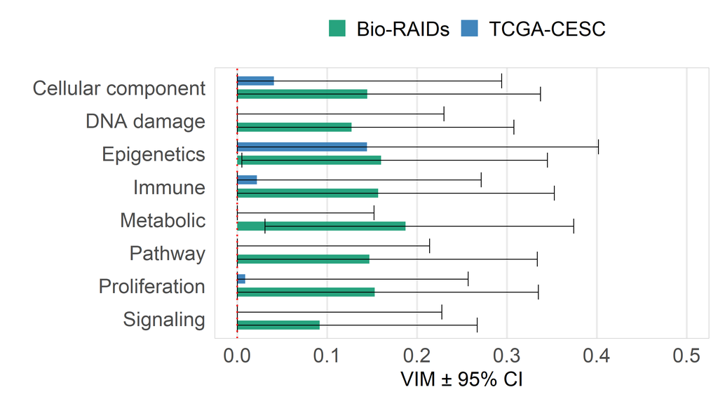

Table 20: Variable importance estimates of DNA-based pathways relative to the base clinical model

| **Pathway** | **Bio-RAIDs** **VIM [95% CI]** | **Bio-RAIDs** *p*-value | **Bio-RAIDs** *q*-value | **TCGA-CESC** **VIM [95% CI]** | **TCGA-CESC** *p*-value | **TCGA-CESC** *q*-value |
| --- | --- | --- | --- | --- | --- | --- |
| Cellular component | 0.145 [0.000–0.337] | 0.070 | 0.094 | 0.041 [0.000–0.294] | 0.4 | 0.7 |
| DNA damage | 0.127 [0.000–0.308] | 0.083 | 0.10 | 0.000 [0.000–0.230] | 0.6 | 0.7 |
| Epigenetics | 0.160 [0.005–0.345] | 0.044 | 0.094 | 0.144 [0.000–0.402] | 0.14 | 0.7 |
| Immune | 0.157 [0.000–0.353] | 0.058 | 0.094 | 0.022 [0.000–0.272] | 0.4 | 0.7 |
| Metabolic | 0.188 [0.031–0.374] | 0.024 | 0.094 | 0.000 [0.000–0.152] | 0.8 | 0.8 |
| Pathway | 0.147 [0.000–0.334] | 0.061 | 0.094 | 0.000 [0.000–0.214] | 0.6 | 0.7 |
| Proliferation | 0.153 [0.000–0.335] | 0.050 | 0.094 | 0.009 [0.000–0.257] | 0.5 | 0.7 |
| Signaling | 0.092 [0.000–0.267] | 0.2 | 0.2 | 0.000 [0.000–0.228] | 0.6 | 0.7 |

VIM: variable importance measure; CI: confidence interval; q-value: Benjamini–Hochberg-adjusted p-value

### 12.1.3 RNA-based pathways

Figure 19: Variable importance estimates of RNA-based pathways relative to the base clinical model

[figure not shown]

Table 21: Variable importance estimates of RNA-based pathways relative to the base clinical model

| **Pathway** | **Bio-RAIDs** **VIM [95% CI]** | **Bio-RAIDs** *p*-value | **Bio-RAIDs** *q*-value | **TCGA-CESC** **VIM [95% CI]** | **TCGA-CESC** *p*-value | **TCGA-CESC** *q*-value |
| --- | --- | --- | --- | --- | --- | --- |
| Adipogenesis | 0.103 [0.000–0.279] | 0.13 | 0.2 | 0.000 [0.000–0.251] | 0.6 | 0.8 |
| Allograft rejection | 0.088 [0.000–0.263] | 0.2 | 0.2 | 0.009 [0.000–0.244] | 0.5 | 0.8 |
| Androgen response | 0.165 [0.011–0.348] | 0.039 | 0.2 | 0.000 [0.000–0.180] | 0.7 | 0.8 |
| Angiogenesis | 0.077 [0.000–0.246] | 0.2 | 0.2 | 0.019 [0.000–0.257] | 0.4 | 0.8 |
| Apical junction | 0.024 [0.000–0.193] | 0.4 | 0.4 | 0.123 [0.000–0.384] | 0.2 | 0.8 |
| Apical surface | 0.099 [0.000–0.278] | 0.14 | 0.2 | 0.015 [0.000–0.269] | 0.5 | 0.8 |
| Apoptosis | 0.131 [0.000–0.304] | 0.070 | 0.2 | 0.000 [0.000–0.168] | 0.7 | 0.8 |
| Bile acide metabolism | 0.156 [0.010–0.330] | 0.040 | 0.2 | 0.000 [0.000–0.135] | 0.8 | 0.8 |
| Cholesterol homeostasis | 0.140 [0.000–0.311] | 0.055 | 0.2 | 0.000 [0.000–0.153] | 0.8 | 0.8 |
| Coagulation | 0.088 [0.000–0.264] | 0.2 | 0.2 | 0.000 [0.000–0.211] | 0.6 | 0.8 |
| Complement | 0.130 [0.000–0.307] | 0.076 | 0.2 | 0.000 [0.000–0.186] | 0.7 | 0.8 |
| DNA repair | 0.087 [0.000–0.262] | 0.2 | 0.2 | 0.002 [0.000–0.248] | 0.5 | 0.8 |
| E2F targets | 0.127 [0.000–0.304] | 0.079 | 0.2 | 0.000 [0.000–0.228] | 0.5 | 0.8 |
| Epithelial mesenchymal transition | 0.067 [0.000–0.244] | 0.2 | 0.3 | 0.023 [0.000–0.262] | 0.4 | 0.8 |
| Early estrogen response | 0.173 [0.022–0.354] | 0.030 | 0.2 | 0.016 [0.000–0.263] | 0.5 | 0.8 |
| Late estrogen response | 0.090 [0.000–0.263] | 0.2 | 0.2 | 0.000 [0.000–0.187] | 0.7 | 0.8 |
| Fatty acid metabolism | 0.092 [0.000–0.271] | 0.2 | 0.2 | 0.008 [0.000–0.251] | 0.5 | 0.8 |
| G2M checkpoint | 0.119 [0.000–0.291] | 0.088 | 0.2 | 0.067 [0.000–0.313] | 0.3 | 0.8 |
| Glycolysis | 0.147 [0.001–0.320] | 0.049 | 0.2 | 0.000 [0.000–0.221] | 0.6 | 0.8 |
| Hedgehog | 0.046 [0.000–0.212] | 0.3 | 0.3 | 0.000 [0.000–0.190] | 0.7 | 0.8 |
| Heme metabolism | 0.016 [0.000–0.192] | 0.4 | 0.4 | 0.000 [0.000–0.222] | 0.7 | 0.8 |
| Hypoxia | 0.124 [0.000–0.299] | 0.083 | 0.2 | 0.000 [0.000–0.231] | 0.5 | 0.8 |
| IL2/STAT5 | 0.182 [0.038–0.353] | 0.019 | 0.2 | 0.000 [0.000–0.210] | 0.6 | 0.8 |
| IL6/JAK/STAT3 | 0.166 [0.015–0.345] | 0.035 | 0.2 | 0.000 [0.000–0.233] | 0.5 | 0.8 |
| Inflammatory response | 0.138 [0.000–0.315] | 0.062 | 0.2 | 0.050 [0.000–0.289] | 0.3 | 0.8 |
| Interferon α response | 0.170 [0.026–0.342] | 0.026 | 0.2 | 0.051 [0.000–0.304] | 0.3 | 0.8 |
| Interferon γ response | 0.163 [0.016–0.339] | 0.034 | 0.2 | 0.067 [0.000–0.313] | 0.3 | 0.8 |
| KRAS: down-regulated genes | 0.049 [0.000–0.221] | 0.3 | 0.3 | 0.000 [0.000–0.206] | 0.6 | 0.8 |
| KRAS: up-regulated genes | 0.078 [0.000–0.258] | 0.2 | 0.2 | 0.000 [0.000–0.212] | 0.6 | 0.8 |
| Mitotic spindle | 0.130 [0.000–0.303] | 0.070 | 0.2 | 0.000 [0.000–0.235] | 0.5 | 0.8 |
| MTORC1 | 0.179 [0.033–0.354] | 0.022 | 0.2 | 0.108 [0.000–0.369] | 0.2 | 0.8 |
| Myc targets variant 1 | 0.090 [0.000–0.262] | 0.2 | 0.2 | 0.000 [0.000–0.223] | 0.7 | 0.8 |
| Myc targets variant 2 | 0.077 [0.000–0.248] | 0.2 | 0.2 | 0.000 [0.000–0.181] | 0.7 | 0.8 |
| Myogenesis | 0.069 [0.000–0.242] | 0.2 | 0.2 | 0.000 [0.000–0.213] | 0.6 | 0.8 |
| Notch | 0.106 [0.000–0.278] | 0.12 | 0.2 | 0.073 [0.000–0.331] | 0.3 | 0.8 |
| Oxidative phosphorylation | 0.083 [0.000–0.261] | 0.2 | 0.2 | 0.000 [0.000–0.266] | 0.6 | 0.8 |
| p53 | 0.103 [0.000–0.279] | 0.13 | 0.2 | 0.000 [0.000–0.227] | 0.5 | 0.8 |
| Pancreas β cells | 0.097 [0.000–0.272] | 0.14 | 0.2 | 0.047 [0.000–0.289] | 0.4 | 0.8 |
| Peroxisome | 0.150 [0.006–0.322] | 0.043 | 0.2 | 0.131 [0.000–0.381] | 0.2 | 0.8 |
| PI3K/AKT/MTOR | 0.116 [0.000–0.293] | 0.10 | 0.2 | 0.000 [0.000–0.119] | 0.8 | 0.8 |
| Protein secretion | 0.078 [0.000–0.250] | 0.2 | 0.2 | 0.109 [0.000–0.354] | 0.2 | 0.8 |
| Reactive oxygen species | 0.084 [0.000–0.263] | 0.2 | 0.2 | 0.000 [0.000–0.213] | 0.6 | 0.8 |
| Spermatogenesis | 0.188 [0.038–0.366] | 0.019 | 0.2 | 0.000 [0.000–0.202] | 0.7 | 0.8 |
| TGF-β | 0.061 [0.000–0.231] | 0.2 | 0.3 | 0.000 [0.000–0.198] | 0.6 | 0.8 |
| TNF-α/NF-κB | 0.089 [0.000–0.268] | 0.2 | 0.2 | 0.000 [0.000–0.216] | 0.6 | 0.8 |
| Unfolded protein response | 0.095 [0.000–0.270] | 0.15 | 0.2 | 0.000 [0.000–0.219] | 0.6 | 0.8 |
| UV response: down-regulated genes | 0.105 [0.000–0.287] | 0.13 | 0.2 | 0.047 [0.000–0.288] | 0.4 | 0.8 |
| UV response: up-regulated genes | 0.100 [0.000–0.277] | 0.13 | 0.2 | 0.000 [0.000–0.225] | 0.6 | 0.8 |
| Wnt/β-catenin | 0.041 [0.000–0.216] | 0.3 | 0.3 | 0.000 [0.000–0.233] | 0.5 | 0.8 |
| Xenobiotic metabolism | 0.133 [0.000–0.306] | 0.067 | 0.2 | 0.000 [0.000–0.229] | 0.6 | 0.8 |

VIM: variable importance measure; CI: confidence interval; q-value: Benjamini–Hochberg-adjusted p-value

### 12.1.4 RNA-based functional categories

Figure 20: Variable importance estimates of RNA-based functional categories relative to the base clinical model

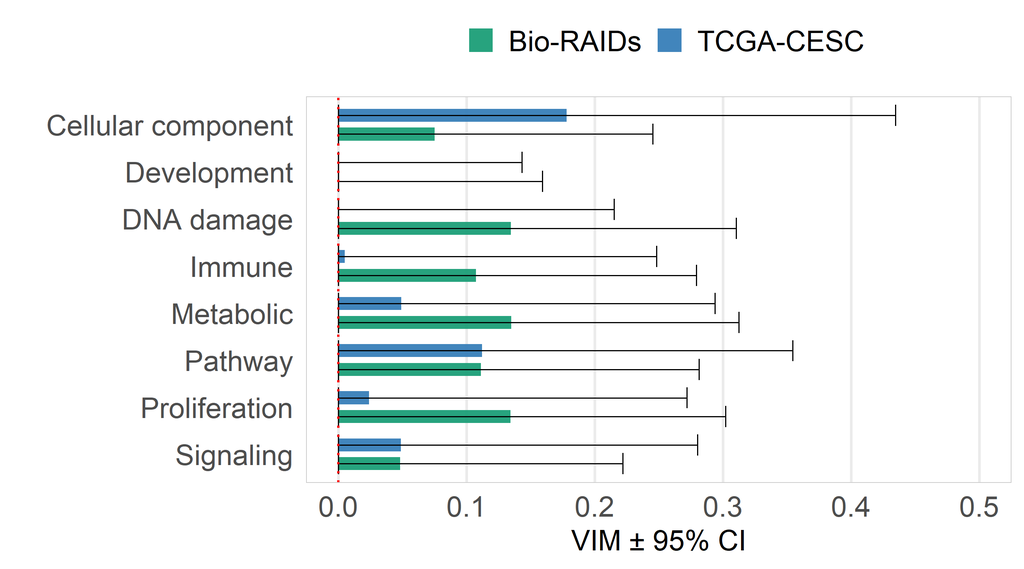

Table 22: Variable importance estimates of RNA-based biological processes relative to the base clinical model

| **Pathway** | **Bio-RAIDs** **VIM [95% CI]** | **Bio-RAIDs** *p*-value | **Bio-RAIDs** *q*-value | **TCGA-CESC** **VIM [95% CI]** | **TCGA-CESC** *p*-value | **TCGA-CESC** *q*-value |
| --- | --- | --- | --- | --- | --- | --- |
| Cellular component | 0.075 [0.000–0.245] | 0.2 | 0.3 | 0.178 [0.000–0.435] | 0.087 | 0.6 |
| DNA damage | 0.135 [0.000–0.310] | 0.066 | 0.2 | 0.000 [0.000–0.215] | 0.6 | 0.7 |
| Development | 0.000 [0.000–0.159] | 0.6 | 0.6 | 0.000 [0.000–0.143] | 0.8 | 0.8 |
| Immune | 0.108 [0.000–0.279] | 0.11 | 0.2 | 0.005 [0.000–0.248] | 0.5 | 0.6 |
| Metabolic | 0.135 [0.000–0.313] | 0.068 | 0.2 | 0.049 [0.000–0.294] | 0.3 | 0.6 |
| Pathway | 0.111 [0.000–0.281] | 0.10 | 0.2 | 0.112 [0.000–0.355] | 0.2 | 0.6 |
| Proliferation | 0.134 [0.000–0.302] | 0.058 | 0.2 | 0.024 [0.000–0.272] | 0.4 | 0.6 |
| Signaling | 0.048 [0.000–0.222] | 0.3 | 0.3 | 0.049 [0.000–0.280] | 0.3 | 0.6 |

VIM: variable importance measure; CI: confidence interval; q-value: Benjamini–Hochberg-adjusted p-value

### 12.1.5 Top-10 features

Table 23: Top-10 variable importance estimates of DNA-based pathways relative to the base clinical model

| **Rank** | **Bio-RAIDs** **Pathway** | **Bio-RAIDs** **VIM [95% CI]** | **Bio-RAIDs** *p*-value | **Bio-RAIDs** *q*-value | **TCGA-CESC** **Pathway** | **TCGA-CESC** **VIM [95% CI]** | **TCGA-CESC** *p*-value | **TCGA-CESC** *q*-value |
| --- | --- | --- | --- | --- | --- | --- | --- | --- |
| 1 | Hippo† | 0.197 [0.033–0.392] | 0.024 | 0.10 | PI3K | 0.110 [0.000–0.367] | 0.2 | 0.7 |
| 2 | Wnt | 0.187 [0.026–0.378] | 0.028 | 0.10 | Hippo† | 0.068 [0.000–0.326] | 0.3 | 0.7 |
| 3 | Transcriptional regulator | 0.185 [0.027–0.373] | 0.027 | 0.10 | Notch | 0.068 [0.000–0.333] | 0.3 | 0.7 |
| 4 | Senescence | 0.184 [0.027–0.371] | 0.027 | 0.10 | Epigenetics† | 0.057 [0.000–0.301] | 0.3 | 0.7 |
| 5 | Cellular metabolism | 0.177 [0.013–0.373] | 0.038 | 0.10 | Chromatin organization | 0.056 [0.000–0.306] | 0.3 | 0.7 |
| 6 | Immunity | 0.168 [0.003–0.365] | 0.047 | 0.10 | Adhesion/Migration | 0.042 [0.000–0.296] | 0.4 | 0.7 |
| 7 | Myc† | 0.159 [0.000–0.359] | 0.059 | 0.10 | JAK/STAT† | 0.027 [0.000–0.284] | 0.4 | 0.7 |
| 8 | JAK/STAT† | 0.159 [0.000–0.355] | 0.056 | 0.10 | Myc† | 0.024 [0.000–0.288] | 0.4 | 0.7 |
| 9 | DNA repair | 0.159 [0.002–0.346] | 0.048 | 0.10 | Hedgehog | 0.020 [0.000–0.279] | 0.4 | 0.7 |
| 10 | Epigenetics† | 0.159 [0.002–0.345] | 0.048 | 0.10 | mRNA processing | 0.020 [0.000–0.279] | 0.4 | 0.7 |

VIM: variable importance measure; CI: confidence interval; q-value: Benjamini–Hochberg-adjusted p-value; † Pathway ranked among the top 10 in both Bio-RAIDs and TCGA-CESC

Table 24: Ranking of variable importance estimates of DNA-based biological processes relative to the base clinical model

| **Rank** | **Bio-RAIDs** **Pathway** | **Bio-RAIDs** **VIM [95% CI]** | **Bio-RAIDs** *p*-value | **Bio-RAIDs** *q*-value | **TCGA-CESC** **Pathway** | **TCGA-CESC** **VIM [95% CI]** | **TCGA-CESC** *p*-value | **TCGA-CESC** *q*-value |
| --- | --- | --- | --- | --- | --- | --- | --- | --- |
| 1 | Metabolic | 0.188 [0.031–0.374] | 0.024 | 0.094 | Epigenetics | 0.144 [0.000–0.402] | 0.14 | 0.7 |
| 2 | Epigenetics | 0.160 [0.005–0.345] | 0.044 | 0.094 | Cellular component | 0.041 [0.000–0.294] | 0.4 | 0.7 |
| 3 | Immune | 0.157 [0.000–0.353] | 0.058 | 0.094 | Immune | 0.022 [0.000–0.272] | 0.4 | 0.7 |
| 4 | Proliferation | 0.153 [0.000–0.335] | 0.050 | 0.094 | Proliferation | 0.009 [0.000–0.257] | 0.5 | 0.7 |
| 5 | Pathway | 0.147 [0.000–0.334] | 0.061 | 0.094 | DNA damage | 0.000 [0.000–0.230] | 0.6 | 0.7 |
| 6 | Cellular component | 0.145 [0.000–0.337] | 0.070 | 0.094 | Metabolic | 0.000 [0.000–0.152] | 0.8 | 0.8 |
| 7 | DNA damage | 0.127 [0.000–0.308] | 0.083 | 0.10 | Pathway | 0.000 [0.000–0.214] | 0.6 | 0.7 |
| 8 | Signaling | 0.092 [0.000–0.267] | 0.2 | 0.2 | Signaling | 0.000 [0.000–0.228] | 0.6 | 0.7 |

VIM: variable importance measure; CI: confidence interval; q-value: Benjamini–Hochberg-adjusted p-value

Table 25: Top-10 variable importance estimates of RNA-based pathways relative to the base clinical model

| **Rank** | **Bio-RAIDs** **Pathway** | **Bio-RAIDs** **VIM [95% CI]** | **Bio-RAIDs** *p*-value | **Bio-RAIDs** *q*-value | **TCGA-CESC** **Pathway** | **TCGA-CESC** **VIM [95% CI]** | **TCGA-CESC** *p*-value | **TCGA-CESC** *q*-value |
| --- | --- | --- | --- | --- | --- | --- | --- | --- |
| 1 | Spermatogenesis | 0.188 [0.038–0.366] | 0.019 | 0.2 | Peroxisome† | 0.131 [0.000–0.381] | 0.2 | 0.8 |
| 2 | IL2/STAT5 | 0.182 [0.038–0.353] | 0.019 | 0.2 | Apical junction | 0.123 [0.000–0.384] | 0.2 | 0.8 |
| 3 | MTORC1† | 0.179 [0.033–0.354] | 0.022 | 0.2 | Protein secretion | 0.109 [0.000–0.354] | 0.2 | 0.8 |
| 4 | Early estrogen response | 0.173 [0.022–0.354] | 0.030 | 0.2 | MTORC1† | 0.108 [0.000–0.369] | 0.2 | 0.8 |
| 5 | Interferon α response† | 0.170 [0.026–0.342] | 0.026 | 0.2 | Notch | 0.073 [0.000–0.331] | 0.3 | 0.8 |
| 6 | IL6/JAK/STAT3 | 0.166 [0.015–0.345] | 0.035 | 0.2 | Interferon γ response† | 0.067 [0.000–0.313] | 0.3 | 0.8 |
| 7 | Androgen response | 0.165 [0.011–0.348] | 0.039 | 0.2 | G2M checkpoint | 0.067 [0.000–0.313] | 0.3 | 0.8 |
| 8 | Interferon γ response† | 0.163 [0.016–0.339] | 0.034 | 0.2 | Interferon α response† | 0.051 [0.000–0.304] | 0.3 | 0.8 |
| 9 | Bile acide metabolism | 0.156 [0.010–0.330] | 0.040 | 0.2 | Inflammatory response | 0.050 [0.000–0.289] | 0.3 | 0.8 |
| 10 | Peroxisome† | 0.150 [0.006–0.322] | 0.043 | 0.2 | UV response: down-regulated genes | 0.047 [0.000–0.288] | 0.4 | 0.8 |

VIM: variable importance measure; CI: confidence interval; q-value: Benjamini–Hochberg-adjusted p-value; † Pathway ranked among the top 10 in both Bio-RAIDs and TCGA-CESC

Table 26: Ranking of variable importance estimates of RNA-based biological processes relative to the base clinical model

| **Rank** | **Bio-RAIDs** **Pathway** | **Bio-RAIDs** **VIM [95% CI]** | **Bio-RAIDs** *p*-value | **Bio-RAIDs** *q*-value | **TCGA-CESC** **Pathway** | **TCGA-CESC** **VIM [95% CI]** | **TCGA-CESC** *p*-value | **TCGA-CESC** *q*-value |
| --- | --- | --- | --- | --- | --- | --- | --- | --- |
| 1 | Metabolic | 0.135 [0.000–0.313] | 0.068 | 0.2 | Cellular component | 0.178 [0.000–0.435] | 0.087 | 0.6 |
| 2 | DNA damage | 0.135 [0.000–0.310] | 0.066 | 0.2 | Pathway | 0.112 [0.000–0.355] | 0.2 | 0.6 |
| 3 | Proliferation | 0.134 [0.000–0.302] | 0.058 | 0.2 | Metabolic | 0.049 [0.000–0.294] | 0.3 | 0.6 |
| 4 | Pathway | 0.111 [0.000–0.281] | 0.10 | 0.2 | Signaling | 0.049 [0.000–0.280] | 0.3 | 0.6 |
| 5 | Immune | 0.108 [0.000–0.279] | 0.11 | 0.2 | Proliferation | 0.024 [0.000–0.272] | 0.4 | 0.6 |
| 6 | Cellular component | 0.075 [0.000–0.245] | 0.2 | 0.3 | Immune | 0.005 [0.000–0.248] | 0.5 | 0.6 |
| 7 | Signaling | 0.048 [0.000–0.222] | 0.3 | 0.3 | DNA damage | 0.000 [0.000–0.215] | 0.6 | 0.7 |
| 8 | Development | 0.000 [0.000–0.159] | 0.6 | 0.6 | Development | 0.000 [0.000–0.143] | 0.8 | 0.8 |

VIM: variable importance measure; CI: confidence interval; q-value: Benjamini–Hochberg-adjusted p-value

### 12.1.6 Univariate Cox regression of top-10 features

Table 27: Univariate Cox regression of top-10 DNA pathways

| **Rank** | **Bio-RAIDs** **Pathway** | **Bio-RAIDs** **HR [95% CI]** | **Bio-RAIDs** **p-value** | **Bio-RAIDs** **q-value** | **TCGA-CESC** **Pathway** | **TCGA-CESC** **HR [95% CI]** | **TCGA-CESC** **p-value** | **TCGA-CESC** **q-value** |
| --- | --- | --- | --- | --- | --- | --- | --- | --- |
| 1 | Hippo† | 0.95 [0.54–1.67] | 0.9 | >0.9 | PI3K | 0.82 [0.50–1.33] | 0.4 | 0.7 |
| 2 | Wnt | 0.79 [0.39–1.58] | 0.5 | >0.9 | Hippo† | 1.14 [0.68–1.93] | 0.6 | 0.7 |
| 3 | Transcriptional regulator | 0.93 [0.60–1.46] | 0.8 | >0.9 | Notch | 0.50 [0.26–0.93] | 0.019 | 0.2 |
| 4 | Senescence | 2.34 [1.41–3.88] | 0.002 | 0.024 | Epigenetics† | 1.54 [0.95–2.50] | 0.078 | 0.2 |
| 5 | Cellular metabolism | 0.99 [0.36–2.71] | >0.9 | >0.9 | Chromatin organization | 1.61 [0.80–3.25] | 0.2 | 0.4 |
| 6 | Immunity | 1.01 [0.55–1.87] | >0.9 | >0.9 | Adhesion/Migration | 0.55 [0.26–1.14] | 0.083 | 0.2 |
| 7 | Myc† | 1.51 [0.37–6.16] | 0.6 | >0.9 | JAK/STAT† | 0.32 [0.08–1.30] | 0.053 | 0.2 |
| 8 | JAK/STAT† | 0.83 [0.36–1.91] | 0.7 | >0.9 | Myc† | 0.73 [0.18–2.99] | 0.6 | 0.7 |
| 9 | DNA repair | 1.32 [0.82–2.10] | 0.3 | 0.9 | Hedgehog | 0.64 [0.09–4.65] | 0.6 | 0.7 |
| 10 | Epigenetics† | 1.31 [0.84–2.03] | 0.2 | 0.9 | mRNA processing | 0.91 [0.22–3.73] | 0.9 | 0.9 |

HR: hazard ratio; CI: confidence interval; q-value: Benjamini–Hochberg-adjusted p-value; † Pathway ranked among the top 10 in both Bio-RAIDs and TCGA-CESC

Table 28: Univariate Cox regression of top-10 RNA pathways

| **Rank** | **Bio-RAIDs** **Pathway** | **Bio-RAIDs** **HR [95% CI]** | **Bio-RAIDs** **p-value** | **Bio-RAIDs** **q-value** | **TCGA-CESC** **Pathway** | **TCGA-CESC** **HR [95% CI]** | **TCGA-CESC** **p-value** | **TCGA-CESC** **q-value** |
| --- | --- | --- | --- | --- | --- | --- | --- | --- |
| 1 | Spermatogenesis | 1.71 [0.54–5.44] | 0.4 | 0.5 | Peroxisome† | 4.89 [1.01–23.7] | 0.048 | 0.12 |
| 2 | IL2/STAT5 | 0.38 [0.12–1.16] | 0.088 | 0.2 | Apical junction | 1.99 [0.65–6.05] | 0.2 | 0.3 |
| 3 | MTORC1† | 2.04 [0.85–4.92] | 0.11 | 0.2 | Protein secretion | 5.01 [1.78–14.1] | 0.002 | 0.009 |
| 4 | Early estrogen response | 0.54 [0.15–1.91] | 0.3 | 0.5 | MTORC1† | 2.13 [0.75–6.01] | 0.2 | 0.3 |
| 5 | Interferon α response† | 0.61 [0.35–1.05] | 0.074 | 0.2 | Notch | 8.45 [2.17–32.9] | 0.002 | 0.009 |
| 6 | IL6/JAK/STAT3 | 0.79 [0.38–1.63] | 0.5 | 0.5 | Interferon γ response† | 0.60 [0.32–1.13] | 0.11 | 0.2 |
| 7 | Androgen response | 0.21 [0.07–0.68] | 0.009 | 0.090 | G2M checkpoint | 1.06 [0.45–2.47] | 0.9 | 0.9 |
| 8 | Interferon γ response† | 0.59 [0.31–1.12] | 0.11 | 0.2 | Interferon α response† | 0.69 [0.40–1.19] | 0.2 | 0.3 |
| 9 | Bile acide metabolism | 0.46 [0.12–1.77] | 0.3 | 0.4 | Inflammatory response | 0.68 [0.31–1.48] | 0.3 | 0.4 |
| 10 | Peroxisome† | 1.62 [0.40–6.64] | 0.5 | 0.5 | UV response: down-regulated genes | 4.63 [1.65–13.0] | 0.004 | 0.012 |

HR: hazard ratio; CI: confidence interval; q-value: Benjamini–Hochberg-adjusted p-value; † Pathway ranked among the top 10 in both Bio-RAIDs and TCGA-CESC

### 12.1.7 Cross-cohort reproducibility

Figure 21: Cross-cohort concordance of pathway-level variable importance estimates

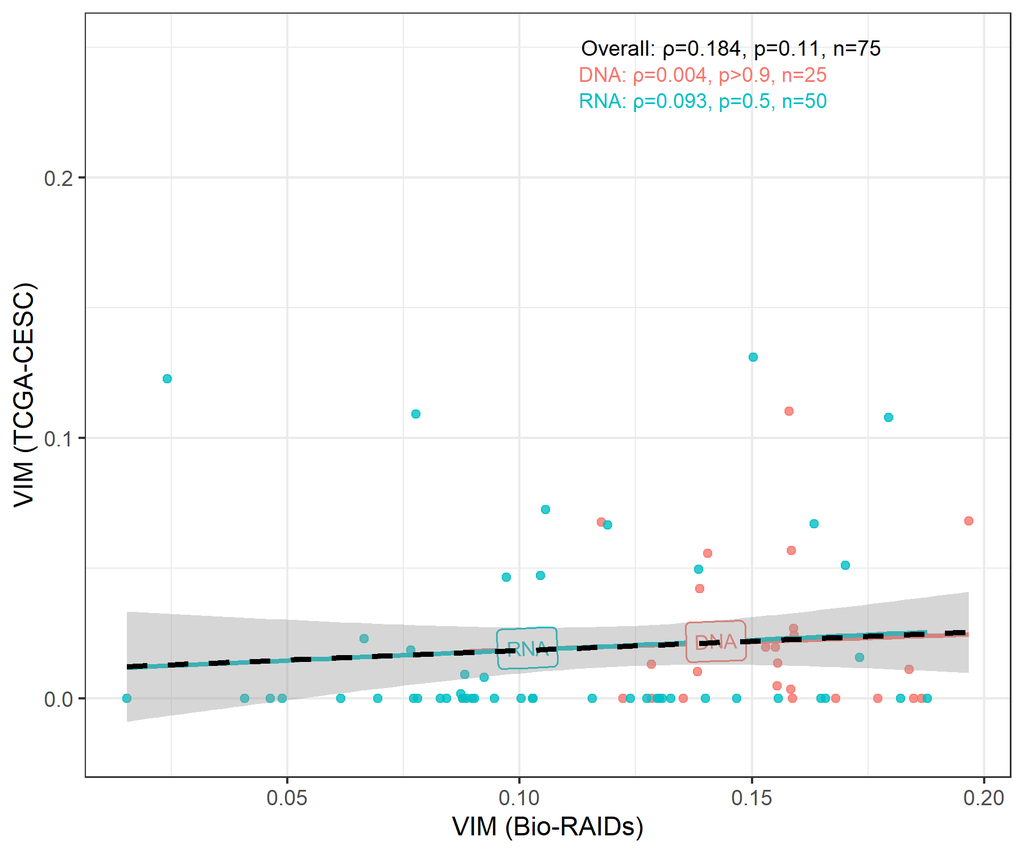

Cross-cohort reproducibility was assessed using complementary measures of agreement, including Spearman’s rank correlation, top-10 pathway overlap, the Jaccard index, and a permutation test evaluating whether the observed overlap exceeded that expected by chance (Table 29).

Table 29: Summary of cross-cohort reproducibility metrics for pathway-level variable importance rankings

(a) Top-5

| Metric | DNA | RNA | Overall |
| --- | --- | --- | --- |
| Spearman's ρ | 0.004 | 0.093 | 0.184 |
| Spearman's p-value | >0.9 | 0.5 | 0.11 |
| Top-5 overlap (%) | 20 | 20 | 0 |
| Top-5 overlapping features | Hippo | MTORC1 |  |
| Jaccard index | 0.11 | 0.11 | 0.00 |
| Permutation p-value (top-5 overlap) | 0.7 | 0.4 | >0.9 |

(b) Top-10

| Metric | DNA | RNA | Overall |
| --- | --- | --- | --- |
| Spearman's ρ | 0.004 | 0.093 | 0.184 |
| Spearman's p-value | >0.9 | 0.5 | 0.11 |
| Top-10 overlap (%) | 40 | 40 | 20 |
| Top-10 overlapping features | Hippo, Myc, JAK/STAT, Epigenetics | MTORC1, Interferon α response, Interferon γ response, Peroxisome | Hippo, MTORC1 |
| Jaccard index | 0.25 | 0.25 | 0.12 |
| Permutation p-value (top-10 overlap) | 0.7 | 0.10 | 0.4 |

(c) Top-20

| Metric | DNA | RNA | Overall |
| --- | --- | --- | --- |
| Spearman's ρ | 0.004 | 0.093 | 0.184 |
| Spearman's p-value | >0.9 | 0.5 | 0.11 |
| Top-20 overlap (%) | 85 | 40 | 40 |
| Top-20 overlapping features | Hippo, Senescence, Cellular metabolism, Immunity, Myc, JAK/STAT, DNA repair, Epigenetics, Oxidative stress, PI3K, Proteins processing, Regulation of gene expression, Hedgehog, mRNA processing, Chromat… | MTORC1, Early estrogen response, Interferon α response, Androgen response, Interferon γ response, Peroxisome, Inflammatory response, G2M checkpoint | Hippo, MTORC1, Interferon α response, Interferon γ response, Myc, JAK/STAT, Epigenetics, PI3K |
| Jaccard index | 0.74 | 0.25 | 0.26 |
| Permutation p-value (top-20 overlap) | 0.3 | 0.6 | 0.2 |

## 12.2 Pooled analysis of Bio-RAIDs and TCGA-CESC in stage I/II cervical cancer patients

### 12.2.1 DNA-based pathways

Figure 22: Variable importance estimates of DNA-based pathways relative to the base clinical model in the pooled analysis of Bio-RAIDs and TCGA-CESC in stage I/II cervical cancer patients

[figure not shown]

### 12.2.2 DNA-based functional categories

Figure 23: Variable importance estimates of DNA-based functional categories relative to the base clinical model in the pooled analysis of Bio-RAIDs and TCGA-CESC in stage I/II cervical cancer patients

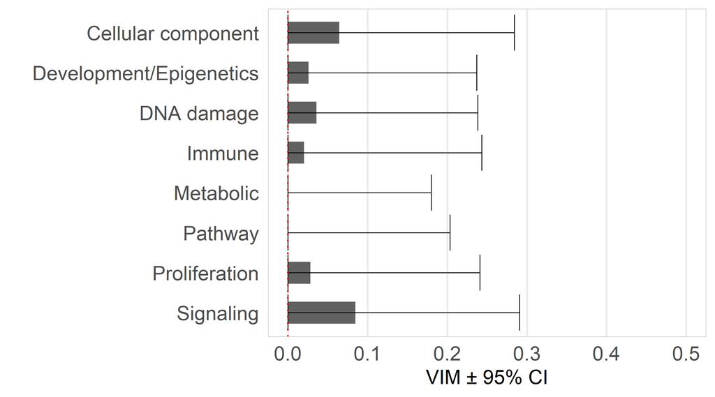

### 12.2.3 RNA-based pathways

Figure 24: Variable importance estimates of RNA-based pathways relative to the base clinical model in the pooled analysis of Bio-RAIDs and TCGA-CESC in stage I/II cervical cancer patients

[figure not shown]

### 12.2.4 RNA-based functional categories

Figure 25: Variable importance estimates of RNA-based functional categories relative to the base clinical model in the pooled analysis of Bio-RAIDs and TCGA-CESC in stage I/II cervical cancer patients

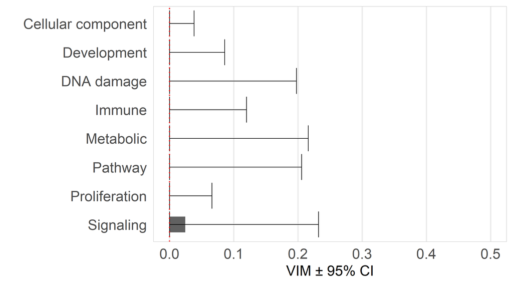

### 12.2.5 Top-10 features

Table 30: Top variable importance estimates in the pooled analysis of Bio-RAIDs and TCGA-CESC in stage I/II cervical cancer patients

(a) DNA-based pathways

| **Rank** | **Pathway** | **VIM [95% CI]** | *p*-value | *q*-value |
| --- | --- | --- | --- | --- |
| 1 | PI3K | 0.134 [0.000–0.350] | 0.11 | 0.6 |
| 2 | DNA repair | 0.122 [0.000–0.327] | 0.12 | 0.6 |
| 3 | mRNA processing | 0.095 [0.000–0.323] | 0.2 | 0.6 |
| 4 | Epigenetics | 0.081 [0.000–0.297] | 0.2 | 0.6 |
| 5 | Senescence | 0.079 [0.000–0.298] | 0.2 | 0.6 |
| 6 | MAPK | 0.071 [0.000–0.291] | 0.3 | 0.6 |
| 7 | Notch | 0.056 [0.000–0.277] | 0.3 | 0.6 |
| 8 | Cellular metabolism | 0.055 [0.000–0.277] | 0.3 | 0.6 |
| 9 | JAK/STAT | 0.053 [0.000–0.283] | 0.3 | 0.6 |
| 10 | Myc | 0.050 [0.000–0.276] | 0.3 | 0.6 |

VIM: variable importance point estimate; CI: confidence interval; q-value: Benjamini–Hochberg-adjusted p-value

(b) DNA-based processes

| **Rank** | **Pathway** | **VIM [95% CI]** | *p*-value | *q*-value |
| --- | --- | --- | --- | --- |
| 1 | Signaling | 0.085 [0.000–0.291] | 0.2 | 0.6 |
| 2 | Cellular component | 0.064 [0.000–0.284] | 0.3 | 0.6 |
| 3 | DNA damage | 0.036 [0.000–0.238] | 0.4 | 0.6 |
| 4 | Proliferation | 0.028 [0.000–0.241] | 0.4 | 0.6 |
| 5 | Development/Epigenetics | 0.026 [0.000–0.237] | 0.4 | 0.6 |
| 6 | Immune | 0.020 [0.000–0.243] | 0.4 | 0.6 |
| 7 | Metabolic | 0.000 [0.000–0.180] | 0.6 | 0.6 |
| 8 | Pathway | 0.000 [0.000–0.203] | 0.6 | 0.6 |

VIM: variable importance point estimate; CI: confidence interval; q-value: Benjamini–Hochberg-adjusted p-value

(c) RNA-based pathways

| **Rank** | **Pathway** | **VIM [95% CI]** | *p*-value | *q*-value |
| --- | --- | --- | --- | --- |
| 1 | MTORC1 | 0.182 [0.006–0.393] | 0.045 | >0.9 |
| 2 | TNF-α/NF-κB | 0.088 [0.000–0.301] | 0.2 | >0.9 |
| 3 | Glycolysis | 0.088 [0.000–0.294] | 0.2 | >0.9 |
| 4 | Heme metabolism | 0.087 [0.000–0.297] | 0.2 | >0.9 |
| 5 | Apoptosis | 0.084 [0.000–0.290] | 0.2 | >0.9 |
| 6 | KRAS: down-regulated genes | 0.076 [0.000–0.282] | 0.2 | >0.9 |
| 7 | Interferon γ response | 0.058 [0.000–0.267] | 0.3 | >0.9 |
| 8 | Reactive oxygen species | 0.049 [0.000–0.254] | 0.3 | >0.9 |
| 9 | Pancreas β cells | 0.044 [0.000–0.272] | 0.4 | >0.9 |
| 10 | Allograft rejection | 0.033 [0.000–0.242] | 0.4 | >0.9 |

VIM: variable importance point estimate; CI: confidence interval; q-value: Benjamini–Hochberg-adjusted p-value

(d) RNA-based processes

| **Rank** | **Pathway** | **VIM [95% CI]** | *p*-value | *q*-value |
| --- | --- | --- | --- | --- |
| 1 | Signaling | 0.025 [0.000–0.232] | 0.4 | >0.9 |
| 2 | Cellular component | 0.000 [0.000–0.038] | >0.9 | >0.9 |
| 3 | DNA damage | 0.000 [0.000–0.198] | 0.6 | >0.9 |
| 4 | Development | 0.000 [0.000–0.086] | 0.9 | >0.9 |
| 5 | Immune | 0.000 [0.000–0.120] | 0.8 | >0.9 |
| 6 | Metabolic | 0.000 [0.000–0.216] | 0.5 | >0.9 |
| 7 | Pathway | 0.000 [0.000–0.206] | 0.5 | >0.9 |
| 8 | Proliferation | 0.000 [0.000–0.066] | >0.9 | >0.9 |

VIM: variable importance point estimate; CI: confidence interval; q-value: Benjamini–Hochberg-adjusted p-value

# References

Binder, Harald, and Martin Schumacher. 2008. “Allowing for Mandatory Covariates in Boosting Estimation of Sparse High-Dimensional Survival Models.” *BMC Bioinformatics* 9 (January): 1–10. https://doi.org/10.1186/1471-2105-9-14.

Goeman, Jelle J., Sara A. Van De Geer, Floor De Kort, and Hans C. Van Houwelingen. 2004. “A Global Test for Groups of Genes: Testing Association with a Clinical Outcome.” *Bioinformatics* 20 (1): 93–99. https://doi.org/10.1093/bioinformatics/btg382.

Lucchesi, Fabiano R, and Natália D Aredes. 2016. “The Cancer Genome Atlas Cervical Squamous Cell Carcinoma and Endocervical Adenocarcinoma Collection (TCGA-CESC).” The Cancer Imaging Archive.

Ngo, Charlotte, Sanne Samuels, Ksenia Bagrintseva, Andrea Slocker, Philippe Hupé, Gemma Kenter, Marina Popovic, et al. 2015. “From Prospective Biobanking to Precision Medicine: BIO-RAIDs – an EU Study Protocol in Cervical Cancer.” *BMC Cancer* 15 (1). https://doi.org/https://doi.org/10.1186/s12885-015-1801-0.

Wolock, Charles J., Brian D. Williamson, Susan M. Shortreed, Gregory E. Simon, Karen J. Coleman, Rodney Yeargans, Brian K. Ahmedani, et al. 2024. “Importance of Variables from Different Time Frames for Predicting Self-Harm Using Health System Data.” *Journal of Biomedical Informatics* 160: 104750. https://doi.org/https://doi.org/10.1016/j.jbi.2024.104750.